# Domaći zadatak 2 — Tri hipoteze

## 3.3 Pitanje 3: Trendovi kroz dekade — da li je “Gourmand era” statistički merljiva?

```r
parfumo_h3 <- parfumo %>%
  filter(
    !is.na(decade),
    !is.na(first_accord),
    first_accord %in% top_accords
  ) %>%
  mutate(
    first_accord = factor(first_accord, levels = top_accords),
    decade       = droplevels(decade)
  )
```

### Motivaciona vizualizacija

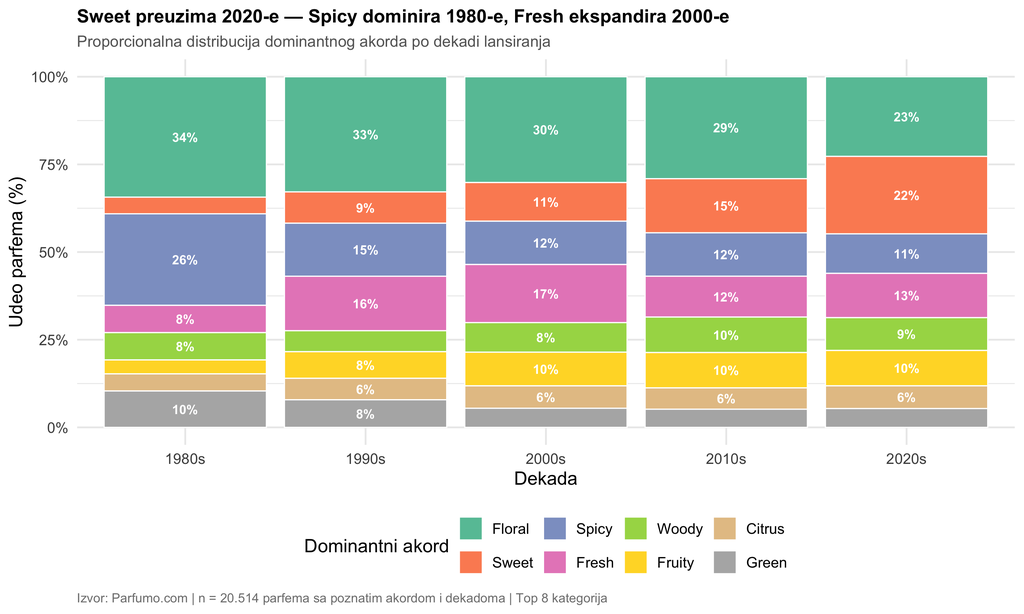

```r
h3_prop <- parfumo_h3 %>%
  count(decade, first_accord) %>%
  group_by(decade) %>%
  mutate(prop = n / sum(n)) %>%
  ungroup()

ggplot(h3_prop, aes(x = decade, y = prop, fill = first_accord)) +
  geom_col(position = "fill", color = "white", linewidth = 0.4) +
  geom_text(
    aes(label = ifelse(prop > 0.06, paste0(round(prop * 100), "%"), "")),
    position = position_fill(vjust = 0.5),
    size = 3.2, color = "white", fontface = "bold"
  ) +
  scale_y_continuous(labels = percent) +
  scale_fill_brewer(palette = "Set2", name = "Dominantni akord") +
  labs(
    title    = "Sweet preuzima 2020-e — Spicy dominira 1980-e, Fresh ekspandira 2000-e",
    subtitle = "Proporcionalna distribucija dominantnog akorda po dekadi lansiranja",
    x        = "Dekada",
    y        = "Udeo parfema (%)",
    caption  = paste0(
      "Izvor: Parfumo.com | n = ", format(nrow(parfumo_h3), big.mark = "."),
      " parfema sa poznatim akordom i dekadoma | Top 8 kategorija"
    )
  ) +
  theme_minimal(base_size = 13) +
  theme(
    plot.title    = element_text(face = "bold", size = 13, lineheight = 1.2),
    plot.subtitle = element_text(color = "gray40", size = 11),
    plot.caption  = element_text(color = "gray50", size = 9, hjust = 0),
    legend.position = "bottom"
  )
```

**Komentar:** Golim okom se vidi promena — Spicy je dominantniji u 1980-ima, Sweet skoro nestaje u 1980-ima pa eksplodira u 2020-ima, a Fresh raste u 2000-ima. Proveravamo da li su ove razlike statistički značajne ili slučajne fluktuacije.

### Provera pretpostavki za hi-kvadrat

```r
tabela_h3 <- table(parfumo_h3$first_accord, parfumo_h3$decade)

ocekivane <- chisq.test(tabela_h3)$expected

cat(sprintf(
  "Minimalna očekivana frekvencija: %.1f\nProcenat ćelija sa očekivanom frekv. < 5: %.1f%%\n",
  min(ocekivane),
  mean(ocekivane < 5) * 100
))
```

```
## Minimalna očekivana frekvencija: 36.9
## Procenat ćelija sa očekivanom frekv. < 5: 0.0%
```

```r
as.data.frame.matrix(round(ocekivane, 1)) %>%
  rownames_to_column("Akord") %>%
  kable(caption = "Očekivane frekvencije po ćeliji — sve moraju biti ≥ 5 za valjanost hi-kvadrata") %>%
  kable_styling(bootstrap_options = c("striped","hover","condensed")) %>%
  column_spec(1, bold = TRUE)
```

Očekivane frekvencije po ćeliji — sve moraju biti ≥ 5 za valjanost hi-kvadrata

| Akord | 1980s | 1990s | 2000s | 2010s | 2020s |
| --- | --- | --- | --- | --- | --- |
| Floral | 186.8 | 405.5 | 1280.7 | 2846.0 | 1131.0 |
| Sweet | 98.0 | 212.7 | 671.9 | 1493.1 | 593.3 |
| Spicy | 83.8 | 181.8 | 574.2 | 1276.1 | 507.1 |
| Fresh | 85.6 | 185.8 | 586.7 | 1303.8 | 518.1 |
| Woody | 60.5 | 131.4 | 415.1 | 922.4 | 366.6 |
| Fruity | 62.9 | 136.6 | 431.5 | 958.9 | 381.1 |
| Citrus | 40.6 | 88.0 | 278.0 | 617.9 | 245.5 |
| Green | 36.9 | 80.1 | 252.9 | 561.9 | 223.3 |

**Komentar:** Sve očekivane frekvencije su ≥ 5 — uslov za hi-kvadrat test je ispunjen. Da je neka ćelija imala očekivanu frekvenciju ispod 5, morali bismo da spojimo kategorije (npr. grupisati rede dekade) ili koristimo Fischerov egzaktni test.

### Hi-kvadrat test nezavisnosti

```r
chisq_h3 <- chisq.test(tabela_h3)
print(chisq_h3)
```

```
##
##  Pearson's Chi-squared test
##
## data:  tabela_h3
## X-squared = 623.48, df = 28, p-value < 2.2e-16
```

**Komentar:** Hi-kvadrat test nam govori da je veza između akorda i dekade statistički značajna — tj. distribucija mirisa po kategorijama nije ista kroz sve dekade. Ali sam test ne govori *gde* su razlike i *koje* kombinacije akord–dekada su nadprosečno ili ispodprosečno zastupljene. To otkriva vizualizacija reziduala ispod.